# 1 Question : How does the level of education affect the type of ownership?

## 1.1 Preparing The data

```r
library(dplyr)
library(ggplot2)
library(tidyverse)
library(RColorBrewer)
```

**merging data**

```r
hh_merged_data <- read.csv("hh_merged_data.csv")
zp_merged_data <- read.csv("zp_merged_data.csv")
```

**Choosing the variables relevant to my question**

There are many variables related to the highest completed education, but I chose the HIGHESTCOMPLEDU variable because it contains sufficient information for this analysis and encompasses the data from all the other related variables.

HOUSEHOLDYEARLYID: Used to link individual and household-level data for consistency and integration.

HIGHESTCOMPLEDU: Represents the highest completed education level, essential for understanding education trends

AGE: Important for analyzing generational differences in education and ownership.

YEAR_QUIZ: Captures the year of data collection, allowing for a temporal analysis.

TYPEOFOWNERSHIP: Provides insights into housing ownership types, which is a key focus of the analysis.

```r
variables_zp <- c("HOUSEHOLDYEARLYID", "HIGHESTCOMPLEDU", "AGE","YEAR_QUIZ")
variables_hh <- c("HOUSEHOLDYEARLYID","TYPEOFOWNERSHIP","YEAR_QUIZ")

zp_selected <- zp_merged_data %>% select(all_of(variables_zp))
hh_selected <- hh_merged_data %>% select(all_of(variables_hh))


complete_edu_and_ownership <- left_join(zp_selected, hh_selected, by = c("HOUSEHOLDYEARLYID", "YEAR_QUIZ"))
```

**Transforming the AGE variable and preparing it for analysis**

```r
complete_edu_and_ownership$agegroup <- cut(
  complete_edu_and_ownership$AGE,
  breaks = c(15, 20, 35, 50, Inf),
  right = FALSE,
  labels = c("Teen", "Young Adult", "Adult", "Mature Adult")
)
```

**Clean and transform the data set**

```r
complete_edu_and_ownership <- complete_edu_and_ownership %>%
  mutate(
    TYPEOFOWNERSHIP = recode(
      as.factor(TYPEOFOWNERSHIP),
      "1" = "Tenant",
      "2" = "Cooperative member",
      "3" = "Condominium owner",
      "4" = "House owner",
      "5" = "Other situation"
    ),
    YEAR_QUIZ = as.factor(YEAR_QUIZ),
    HIGHESTCOMPLEDU = recode(
      as.factor(HIGHESTCOMPLEDU),
      "1" = "None",
      "2" = "Compulsory Education",
      "3" = "Compulsory Education",
      "4" = "Secondary Schooling",
      "5" = "Secondary Schooling",
      "6" = "Basic Vocational Education and Training",
      "7" = "Secondary Schooling",
      "8" = "Secondary Schooling",
      "9" = "Higher Vocational and Professional Education and Training",
      "10" = "Higher Vocational and Professional Education and Training",
      "11" = "Universities and Higher Education Institutions",
      "12" = "Universities and Higher Education Institutions",
      "13" = "Universities and Higher Education Institutions"
    )
  )


cleaned_data <- complete_edu_and_ownership %>%
  filter(
    !HIGHESTCOMPLEDU %in% c("-9", "None"),
    !TYPEOFOWNERSHIP %in% c("-9","Unknown/Missing"),
    !is.na(TYPEOFOWNERSHIP)
  ) %>%
  mutate(HIGHESTCOMPLEDU = droplevels(HIGHESTCOMPLEDU))
```

*Here is a brief explanation of the TYPEOFOWNERSHIP variable:*

Tenant - Individuals renting an apartment or house. Cooperative Member - Individuals who are members of a housing cooperative. Condominium Owner - Owners of an apartment or unit in a building. House Owner - Owners of an entire house. Other Situations - Includes cases where housing is provided free by a relative or employer, service apartments (e.g., caretaker’s apartment), or leased by a tenant.

## 1.2 Plots

**How is ownership type distributed across different education levels?**

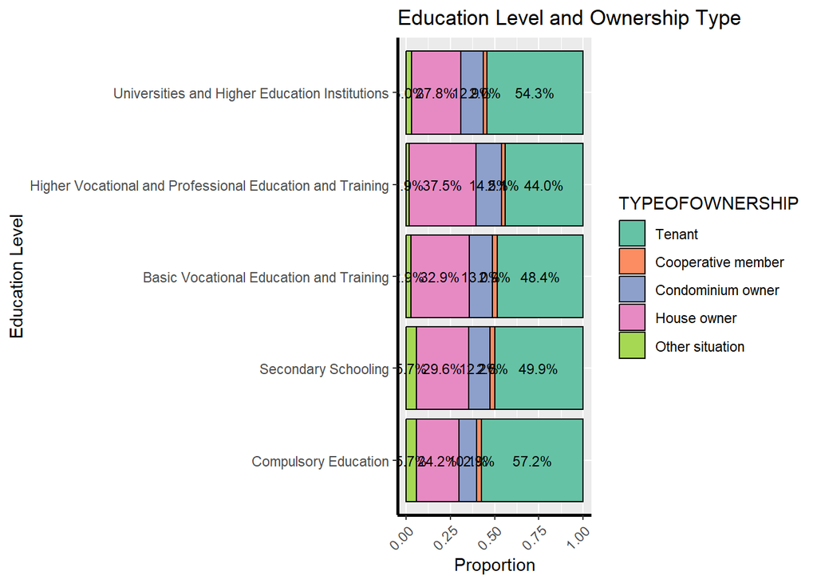

```r
proportions_data <- cleaned_data %>%
  count(HIGHESTCOMPLEDU, TYPEOFOWNERSHIP) %>%
  group_by(HIGHESTCOMPLEDU) %>%
  mutate(Proportion = n / sum(n)) %>%
  arrange(desc(Proportion), .by_group = TRUE)

ggplot(proportions_data, aes(x = HIGHESTCOMPLEDU, y = Proportion, fill = TYPEOFOWNERSHIP)) +
  geom_bar(stat = "identity", position = "fill",color = "black") +
  geom_text(
    aes(label = scales::percent(Proportion, accuracy = 0.1)),
    position = position_fill(vjust = 0.5),
    size = 3
  ) +
  scale_fill_brewer(palette = "Set2") +
  theme(axis.text.x = element_text(angle = 45, hjust = 1),
        axis.line = element_line(size = 1)) +
  labs(
    title = "Education Level and Ownership Type",
    x = "Education Level",
    y = "Proportion"
  )+
  coord_flip()
```

Without considering age, renting a house is the most dominant ownership type across all education groups.

**What ownership types are more common in specific age groups?**

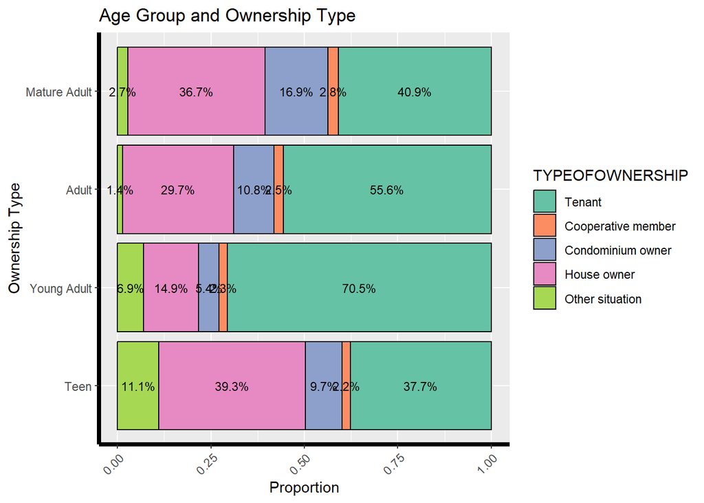

```r
ggplot(cleaned_data, aes(x = agegroup, fill = TYPEOFOWNERSHIP)) +
  geom_bar(position = "fill", color = "black") +
  geom_text(
    aes(label = scales::percent(..count../tapply(..count.., ..x.., sum)[..x..], accuracy = 0.1)),
    stat = "count",
    position = position_fill(vjust = 0.5),
    size = 3
  ) +
  theme(
    axis.text.x = element_text(angle = 45, hjust = 1),
    axis.line = element_line(size = 1.5)
  ) +
  scale_fill_brewer(palette = "Set2") +
  labs(
    title = "Age Group and Ownership Type",
    x = "Ownership Type",
    y = "Proportion"
  ) +
  coord_flip()
```

**Analyzing the age distribution across different ownership types.**

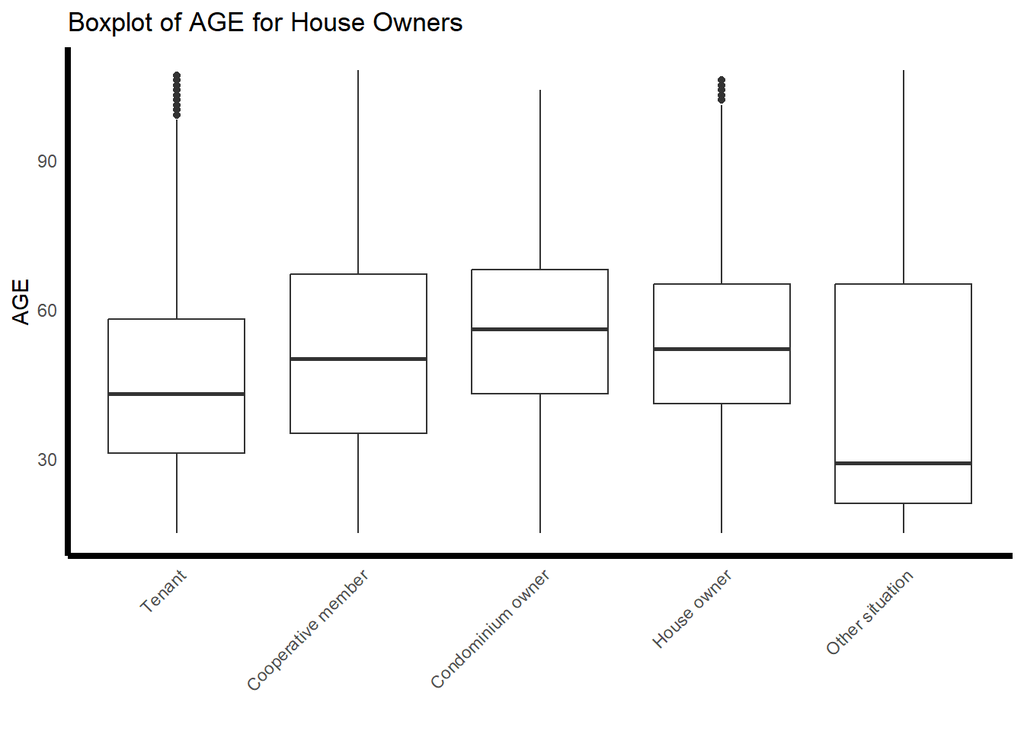

```r
cleaned_data %>%
  ggplot(aes(x = TYPEOFOWNERSHIP, y = AGE)) +
  geom_boxplot() +
  labs(title = "Boxplot of AGE for House Owners", x = "", y = "AGE") +
  theme_minimal() +
  theme(
    axis.text.x = element_text(angle = 45, hjust = 1),
    axis.line = element_line(color = "black", size = 1.5),
    panel.grid = element_blank()
  )
```

“Tenants” and “Other Situations” exhibit broader age ranges, while “Condominium Owners” and “House Owners” show more consistent distributions.

**How have the proportions of ownership types and highest education levels changed over the years ?**

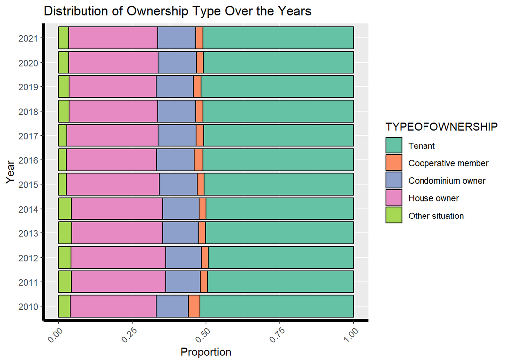

```r
ggplot(cleaned_data, aes(x = YEAR_QUIZ, fill = TYPEOFOWNERSHIP)) +
  geom_bar(position = "fill", color = "black") +
  scale_fill_brewer(palette = "Set2") +
  theme(
    axis.text.x = element_text(angle = 45, hjust = 1),
    axis.line = element_line(size = 1.5)
  ) +
  labs(
    title = "Distribution of Ownership Type Over the Years",
    x = "Year",
    y = "Proportion"
  ) +
  coord_flip()
```

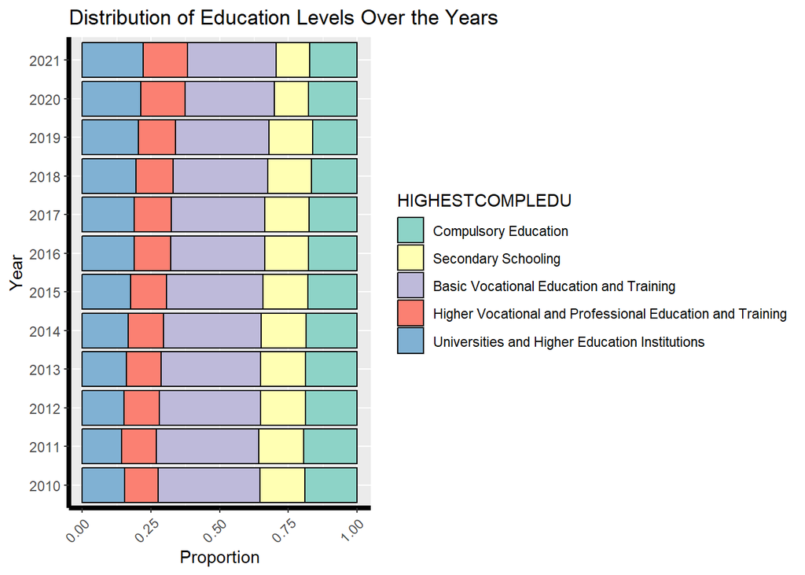

```r
ggplot(cleaned_data, aes(x = YEAR_QUIZ, fill = HIGHESTCOMPLEDU)) +
  geom_bar(position = "fill", color = "black") +
  scale_fill_brewer(palette = "Set3") +
  theme(
    axis.text.x = element_text(angle = 45, hjust = 1),
    axis.line = element_line(size = 1.5)
  ) +
  labs(
    title = "Distribution of Education Levels Over the Years",
    x = "Year",
    y = "Proportion"
  ) +
  coord_flip()
```

**Interplay of Multiple Factors**

**Does the combination of education and age groups influence ownership type ?**

**Are there distinct patterns of ownership types for individuals with different education levels across various age groups?**

**How do the distributions of ownership types vary when both age group and education level are considered simultaneously?**

```r
grouped_data <- cleaned_data %>%
  group_by(agegroup, HIGHESTCOMPLEDU, TYPEOFOWNERSHIP) %>%
  summarise(Count = n()) %>%
  mutate(Proportion = Count / sum(Count))
```

[figure not shown]

```r
ggplot(grouped_data, aes(x = HIGHESTCOMPLEDU, y = Proportion, fill = TYPEOFOWNERSHIP)) +
  geom_bar(stat = "identity", color = "black") +
  geom_text(
    aes(label = scales::percent(Proportion, accuracy = 0.1)),
    position = position_stack(vjust = 0.5),
    size = 2.3
  ) +
  facet_wrap(~ agegroup, scales = "free") +
  scale_fill_brewer(palette = "Set3") +
  labs(
    title = "Ownership Types by Age Group and Education Level",
    x = "Age Group",
    y = "Proportion"
  ) +
  theme(axis.text.x = element_text(angle = 45, hjust = 1))
```

The proportion of Property Owners also increases in older age groups, particularly for mid-to-high education levels.

“Tenant” remains dominant even in older age groups.